# scRNASeq analysis of cycling cardiomyocytes

## 0.5 Differential gene expression analysis

Here we use the `pagoda2` package to normalize the gene counts and then identify genes that are (1) differentially expressed between each group of cells vs. the other groups and (2) also on average more highly expressed in each group vs. both the other groups. We will restrict our analysis to cells that are TMEM88 or TNNT2 positive (cardiomyocytes and/or cardiomyocyte progenitors).

The code below shows how the raw counts were extracted from the 10X Chromium run and how they were filtered. The raw output from the 10X Chromium pipeline is not provided here due to file size (but is available from GEO), but this repository contains the filtered raw counts for use in both the pagoda and AUCell analyses below.

```r
root <- "./final_data/outs/"

countMatrix <- read.10x.matrices(
  paste0(root, "filtered_gene_bc_matrices_mex/GRCh38/")
)
cd <- clean.counts(as.matrix(countMatrix),
                   min.lib.size=1000,
                   min.reads = 1,
                   min.detected = 1)
cd <- apply(cd, 2, function(x) { storage.mode(x) <- 'integer'; x})
colnames(cd) <- gsub("^.*_", "", colnames(cd))

# restrict to cardiomyocytes or cardiomyocyte precursors
ix <-  which(rownames(cd) == "TMEM88")[1]
ix2 <-  which(rownames(cd) == "TNNT2")[1]
cd <- cd[, which(cd[ix,] > 0 | cd[ix2,] > 0)]

# these raw counts are used later by AUCell
saveRDS(cd, "final_data/filtered_count_matrix.rds")

#normalize and filter using pagoda defaults
counts <- gene.vs.molecule.cell.filter(cd)
#counts <- counts[ rowSums(as.matrix(counts)) >= 10,]
rownames(counts) <- make.unique(rownames(counts))
saveRDS(counts, file="final_data/counts.rds")
pag <- Pagoda2$new(counts, log.scale = TRUE, n.cores = 8)
pag$adjustVariance(plot = FALSE, gam.k = 10)
pag <- saveRDS(pag, file="final_data/pagoda_object.rds")
```

We can then load the cell annotations (cell cycle and CDC level as quantified by molecular beacons) from the provided metadata file and identify differentially expressed genes between the cell populations.

The resulting pagoda data object is saved to file for future reference.

```r
# identify differentially expressed genes
pd <- readRDS("final_data/cycling_metadata.rds")
sg <- pd$type_cdc20
sg <- sg[which(pd$barcode %in% rownames(pag$counts))]
names(sg) <- rownames(pag$counts)
sg <- factor(sg)
sg2 <- pd$type
sg2 <- sg2[which(pd$barcode %in% rownames(pag$counts))]
sg2 <- factor(sg2)

pag$misc$groups <- sg
pag$getDifferentialGenes(groups = pag$misc$groups, upregulated.only = FALSE, z.threshold=0)
saveRDS(pag, file="final_data/pagoda_object.rds")
```

A volcano plot of this analysis was generated as follows, which is presented in the manuscript as supplemental figure 4a.

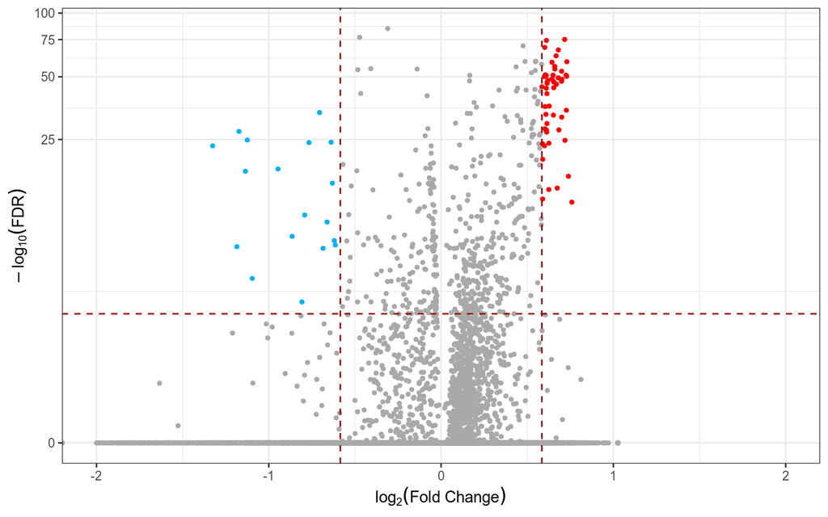

```r
pag <- readRDS(file="final_data/pagoda_object.rds")
oe <- pag$diffgenes$counts$customClustering$G2M_pos
pv <- 2*pnorm(-abs(oe$Z))
pv.adj <- p.adjust(pv, "BH")

color <- rep("dark gray", nrow(oe))
color[oe$M < -0.5849625 & pv.adj < 0.001] <- "#00B2FF"
color[oe$M > 0.5849625 & pv.adj < 0.001] <- "red"
dat <- data.frame(logFC = oe$M, logP = -log10(pv.adj), color=color)

ggplot(dat, aes(x = logFC, y = logP, color = color)) +
  scale_colour_manual(values = c("#00B2FF", "dark gray", "red")) +
  geom_point(size = 1, alpha = 1, na.rm = T) +
  scale_y_continuous(trans = "log1p") +
  ylab(expression(-log[10]("FDR"))) +
  xlab(expression(log[2]("Fold Change"))) +
  geom_hline(yintercept = 3, colour="#990000", linetype="dashed") +
  geom_vline(xintercept = 0.5849625, colour="#990000", linetype="dashed") +
  geom_vline(xintercept = -0.5849625, colour="#990000", linetype="dashed") +
  xlim(-2, 2) +
  theme_bw() +
  theme(legend.position = 'none')
```

```r
ix <- which(oe$M > 0.5849625 & pv.adj < 0.001)
ix.d <- which(oe$M <= -0.5849625 & pv.adj <= 0.001)
```

The most significant 25 genes are listed in the table below.

```r
knitr::kable(oe[1:25,], caption = "Genes up-regulated in CDC20+ cells")
```

Table 1: Genes up-regulated in CDC20+ cells

|  | Z | M | highest | fe |
| --- | --- | --- | --- | --- |
| UBE2C | 18.89627 | 0.7172941 | TRUE | 0.9973333 |
| KPNA2 | 18.78128 | 0.6112366 | TRUE | 0.9946667 |
| CKS1B | 18.24209 | 0.4759573 | TRUE | 0.9973333 |
| TUBB4B | 18.08544 | 0.6020607 | TRUE | 1.0000000 |
| AURKB | 17.83800 | 0.6805243 | TRUE | 0.9733333 |
| TOP2A | 17.28908 | 0.6676811 | FALSE | 0.9760000 |
| ARL6IP1 | 16.78854 | 0.5497506 | TRUE | 0.9946667 |
| CKS2 | 16.76439 | 0.4871561 | FALSE | 0.9946667 |
| PLK1 | 16.73100 | 0.7301925 | FALSE | 0.9173333 |
| CENPF | 16.73014 | 0.5476977 | TRUE | 0.9840000 |
| CCNB1 | 16.68704 | 0.6437951 | TRUE | 0.9680000 |
| NUSAP1 | 16.50129 | 0.5835650 | TRUE | 0.9813333 |
| TPX2 | 16.31846 | 0.6595583 | TRUE | 0.9573333 |
| HMGB2 | 16.26544 | 0.4351368 | TRUE | 1.0000000 |
| CDC20 | 16.07539 | 0.6600281 | TRUE | 0.9413333 |
| PTTG1 | 15.94141 | 0.5465879 | TRUE | 0.9946667 |
| SGOL2 | 15.87813 | 0.6995037 | TRUE | 0.9013333 |
| BIRC5 | 15.75013 | 0.5240332 | TRUE | 0.9813333 |
| CCNA2 | 15.57537 | 0.6052556 | FALSE | 0.9520000 |
| DLGAP5 | 15.54129 | 0.6503081 | TRUE | 0.9093333 |
| AURKA | 15.54129 | 0.7252022 | TRUE | 0.8720000 |
| TUBA1B | 15.52361 | 0.1663709 | TRUE | 1.0000000 |
| FAM64A | 15.51363 | 0.6102816 | TRUE | 0.9306667 |
| CDCA3 | 15.44178 | 0.7291824 | FALSE | 0.8586667 |
| NUF2 | 15.41694 | 0.5995195 | FALSE | 0.9546667 |

## 0.6 Functional Analysis

### 0.6.1 Cell cycle gene enrichment

We can examine the functional the differentially expressed genes identified above by calculating enrichment in GO terms via the hypergeometric test. The most enriched terms are shown in the figure 5b & c, generated below.

```r
# note that using SYMBOLS causes enrichGO to fail (as it tries to convert
# the SYMBOLS to SYMBOLS which results in fewer columns of gene ids than
# the function expects).  So we convert to entrez gene id.

symToEg <- function(x) {
  ix <- which(x %in% ls(org.Hs.egSYMBOL2EG))
  eg <- unlist(mget(x[ix], org.Hs.egSYMBOL2EG))
  return(unique(eg))
}

bg <- colnames(pag$counts)
oe <- pag$diffgenes$counts$customClustering$G2M_pos
oe.sig.up <- rownames(oe[ix,])
oe.sig.down <- rownames(oe[ix.d,])


ego.u <- enrichGO(gene = symToEg(oe.sig.up),
                OrgDb = org.Hs.eg.db,
                ont = "BP",
                pAdjustMethod = "BH",
                qvalueCutoff = 0.05,
                readable = TRUE)

pdf(file="fig5b.pdf", width = 2500/300, height=2500/300, family = font_family)
g <- dotplot(ego.u, showCategory=30)
```

```
## wrong orderBy parameter; set to default `orderBy = "x"`
```

```r
print(g)
dev.off()
```

```r
ego.d <- enrichGO(gene = symToEg(oe.sig.down),
                OrgDb = org.Hs.eg.db,
                ont = "BP",
                pAdjustMethod = "BH",
                qvalueCutoff = 0.05,
                readable = TRUE)

pdf(file="fig5c.pdf", width = 2800/300, height=1500/300, family = font_family)
g <- dotplot(ego.d, showCategory=30)
```

```
## wrong orderBy parameter; set to default `orderBy = "x"`
```

```r
print(g)
dev.off()
```

```r
library(ggplot2)
library(ggpubr)
# set dryrun = TRUE to test the plotting without permutation based sig tests (much
# faster for optimizing plot labels, etc.). The test parameter should be one of
# 't', 'perm', or 'auto' (in which case the permutation based test is used only if
# abs(skewness(data$value)) > 0.5)
plot_auc <- function(data, title = " ",
                     comparisons,
                     adjust=TRUE,
                     test="auto",
                     dryrun = FALSE,
                     scales = "fixed") {
  # normality and variance diagnostics
  print(ggqqplot(data, x = "value", facet.by = c("class", "variable")))

  skewed <- abs(skewness(data$value)) > 0.5
  print(paste0("SKEWNESS ", skewness(data$value)))

  ttest <- function(a,b) {
    p <- t.test(a, b, var.equal=FALSE)$p.value
    if(adjust) {
      p <- p * (length(comparisons) * length(levels(data$variable)))
    }
    p <- ifelse(p < 0.0001, "<0.0001", round(p,4))
    p <- ifelse(p > 0.05, "ns", p)
    return(list(p.value = p))
  }

  permtest <- function(a, b) {
    if(dryrun) return(list(p.value="dryrun"))
    d <- c(a,b)
    grp <- c(rep('a', length(a)),
             rep('b', length(b)))
    dat <- data.frame(value=d, group=grp)
    set.seed(1000)
    p <- GFD::GFD(value ~ grp, data=dat, nperm = 100000)$WTS["p-value WTPS"]
    if(adjust) {
      p <- p * (length(comparisons) * length(levels(data$variable)))
    }
    p <- ifelse(p < 0.0001, "<0.0001", round(p,4))
    p <- ifelse(p > 0.05, "ns", p)
    list(p.value=p)
  }

  # diagnostics
  if(test == "perm" || (test == "auto" && skewed)) {
    if(length(levels(data$variable)) > 1 && !dryrun) {
      print("Permuted Wald Type Test (GFD package):")
      tr.gfd <- GFD::GFD(value ~ class + variable, data = data)
      print(tr.gfd)
    } else if (!dryrun) {
      print("Permuted Wald Type Test (GFD package):")
      tr.gfd <- GFD::GFD(value ~ class, data = data)
      print(tr.gfd)
    }
  } else {
     if(!dryrun) {
        print("### ONE WAY ANOVA")
        print(summary(aov(value ~ class, data=data)))
     }
     if(length(levels(data$variable)) > 1 && !dryrun) {
      print("TWO WAY ANOVA:")
      rv <- data$value
      print(summary(aov(rv ~ class + variable, data=data)))
     }
  }

  if(test == "perm" || (test == "auto" && skewed)) {
    print(" ##### USING PERMUTATION BASED SIGNIFICANCE TESTING ####")
    sigtest <- permtest
  } else {
    print(" ##### USING PARAMETRIC SIGNIFICANCE TESTING ####")
    sigtest <- ttest
  }

  p <- ggplot(data, aes(class, value)) +
    geom_jitter(aes(color = class),
                height = 0.01,
                width = 0.1,
                alpha = 0.5,
                shape = 20, size = 1) +
    geom_violin(alpha = 0.3) +
    ggsignif::geom_signif(comparisons = comparisons, family = font_family,
                          textsize = 3,
                          vjust = -.2,
                          step_increase = .18,
                          test=sigtest) +
    theme_bw() +
    scale_y_continuous(expand = c(0.2, 0)) +
    ggtitle(title) +
    theme(axis.title.x=element_blank(),
      axis.text.x=element_blank(),
      axis.ticks.x=element_blank()) +
    ylab("AUC Enrichment Score") +
    facet_wrap(~variable,
               ncol = 3,
               scales = scales)
  p
}
```

We then load the cell cycle signatures defined by McCarroll et al. and Glotzer et al, calculate enrichment scores for each signature and each cell and plot results.

```
##     min      1%      5%     10%     50%    100%
## 1017.00 1530.55 2228.55 2968.80 5100.50 9965.00
```

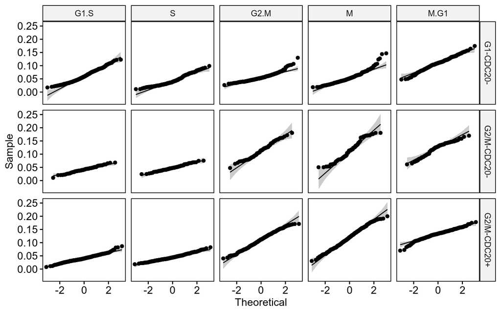

```
## [1] "SKEWNESS 0.472558516384737"
## [1] "### ONE WAY ANOVA"
##               Df Sum Sq Mean Sq F value Pr(>F)
## class          2  0.769  0.3845   251.8 <2e-16 ***
## Residuals   5067  7.737  0.0015
## ---
## Signif. codes:  0 '***' 0.001 '**' 0.01 '*' 0.05 '.' 0.1 ' ' 1
## [1] "TWO WAY ANOVA:"
##               Df Sum Sq Mean Sq F value Pr(>F)
## class          2  0.769  0.3845   596.3 <2e-16 ***
## variable       4  4.473  1.1182  1734.1 <2e-16 ***
## Residuals   5063  3.265  0.0006
## ---
## Signif. codes:  0 '***' 0.001 '**' 0.01 '*' 0.05 '.' 0.1 ' ' 1
## [1] " ##### USING PARAMETRIC SIGNIFICANCE TESTING ####"
```

```r
tab2sig <- function(file) {
  data <- read.delim(file, as.is=TRUE, stringsAsFactors = FALSE, header=TRUE)
  res <- apply(data, 2, function (x) {
    x <- gsub(" ", "", x)
    x <- x[which(x != "")]
  })
  res
}

cd <- readRDS("final_data/filtered_count_matrix.rds")
pd <- readRDS("final_data/cycling_metadata.rds")
sg <- pd$type_cdc20
sg <- sg[which(pd$barcode %in% colnames(cd))]
names(sg) <- colnames(cd)
sg <- factor(sg)

sg2 <- pd$type
sg2 <- sg2[which(pd$barcode %in% colnames(cd))]
names(sg2) <- colnames(cd)
sg2 <- factor(sg2)



auc_mccaroll <- function(dryrun = FALSE) {
  sigs <- tab2sig("final_data/signatures/cell_cycle_mccarroll.txt")
  set.seed(1000)
  cells_rankings <- AUCell_buildRankings(cd, nCores=12, plotStats=FALSE)
  cells_AUC <- AUCell_calcAUC(sigs, cells_rankings)
  dat <- as.data.frame(t(getAUC(cells_AUC)))
  dat$class <- sg
  dat <- melt(dat, id.vars = c("class"))
  dat$class <- factor(dat$class, labels = c("G1-CDC20-",
                                        "G2/M-CDC20-",
                                        "G2/M-CDC20+"))
  comparisons <- list( c("G2/M-CDC20+", "G2/M-CDC20-"),
                   c("G1-CDC20-", "G2/M-CDC20-"),
                   c("G1-CDC20-", "G2/M-CDC20+"))


  plot_auc(dat, test="auto", comparisons = comparisons, dryrun = dryrun) +
    scale_color_discrete(labels=c(expression(paste("G1-", italic("CDC20"), ""^low)),
                                  expression(paste("G2/M-", italic("CDC20"), ""^low)),
                                  expression(paste("G2/M-", italic("CDC20"), ""^high)))) +
    theme(legend.text.align = 0) +
    labs(color="")
}

p <- auc_mccaroll() +
      guides(color = guide_legend(override.aes = list(size = 4)))
```

```r
pdf(file="fig5a.pdf", width = 2000/300, height=1800/300, family = font_family)
print(p)
dev.off()
```

```
##     min      1%      5%     10%     50%    100%
## 1017.00 1530.55 2228.55 2968.80 5100.50 9965.00
```

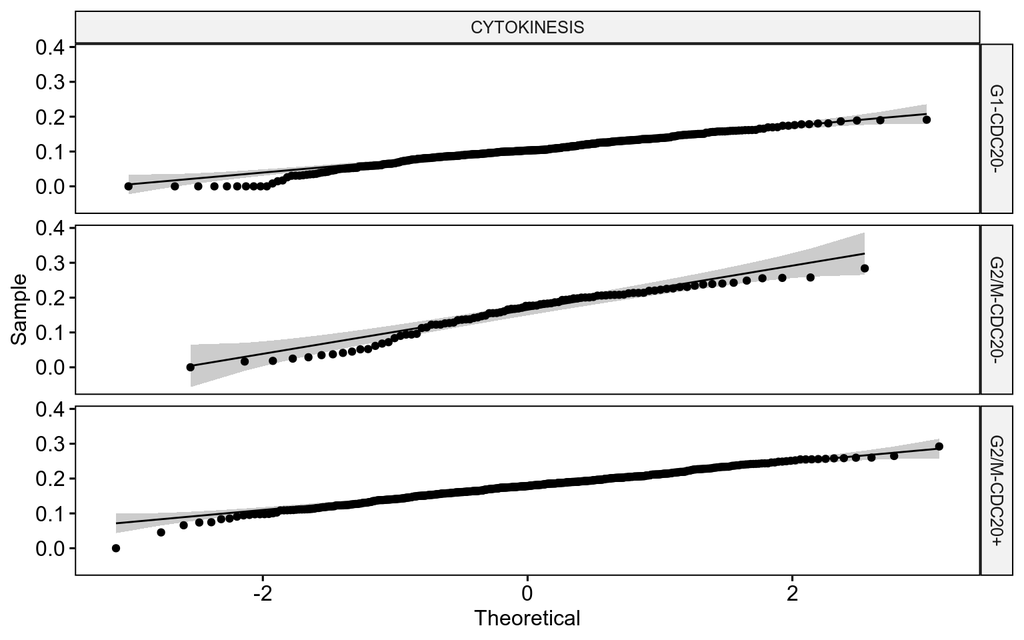

```
## [1] "SKEWNESS -0.269799080275598"
## [1] "### ONE WAY ANOVA"
##               Df Sum Sq Mean Sq F value Pr(>F)
## class          2  1.263  0.6316   372.4 <2e-16 ***
## Residuals   1011  1.715  0.0017
## ---
## Signif. codes:  0 '***' 0.001 '**' 0.01 '*' 0.05 '.' 0.1 ' ' 1
## [1] " ##### USING PARAMETRIC SIGNIFICANCE TESTING ####"
```

```r
auc_glotzer <- function(dryrun = FALSE) {
  sigs <- tab2sig("final_data/signatures/CYTOKINESES_GLOTZER.txt")
  sigs <- as.data.frame(sigs)
  set.seed(1000)
  cells_rankings <- AUCell_buildRankings(cd, nCores=4, plotStats=FALSE)
  cells_AUC <- AUCell_calcAUC(sigs, cells_rankings)
  dat <- as.data.frame(t(getAUC(cells_AUC)))
  dat$class <- sg
  dat <- melt(dat, id.vars = c("class"))
  dat$class <- factor(dat$class, labels = c("G1-CDC20-",
                                        "G2/M-CDC20-",
                                        "G2/M-CDC20+"))
  comparisons <- list( c("G2/M-CDC20+", "G2/M-CDC20-"),
                   c("G1-CDC20-", "G2/M-CDC20-"),
                   c("G1-CDC20-", "G2/M-CDC20+"))
  plot_auc(dat, title=" ", comparisons = comparisons, dryrun = dryrun) +
    scale_color_discrete(labels=c(expression(paste("G1-", italic("CDC20"), ""^low)),
                                  expression(paste("G2/M-", italic("CDC20"), ""^low)),
                                  expression(paste("G2/M-", italic("CDC20"), ""^high)))) +
    theme(legend.text.align = 0)
}

p <- auc_glotzer() +
    labs(color="") +
    guides(color = guide_legend(override.aes = list(size = 4)))
```

```r
pdf(file="fig5d.pdf", width = 1000/300, height=900/300, family = font_family)
print(p)
dev.off()
```

We can further stratify by SPG20 and repeat the above analysis.

```
##     min      1%      5%     10%     50%    100%
## 1017.00 1530.55 2228.55 2968.80 5100.50 9965.00
```

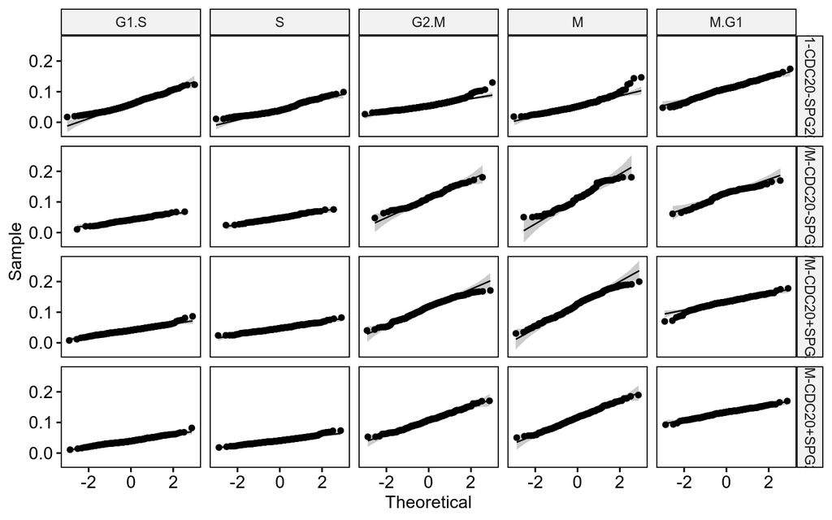

```
## [1] "SKEWNESS 0.472558516384737"
## [1] "Permuted Wald Type Test (GFD package):"
## Call:
## value ~ class + variable
## <environment: 0x56430f024840>
##
## Wald-Type Statistic (WTS):
##          Test statistic df p-value p-value WTPS
## class          2073.782  3       0            0
## variable      25177.688 16       0            0
##
## ANOVA-Type Statistic (ATS):
##          Test statistic      df1      df2 p-value
## class          303.4568 1.989607 702.3665       0
## variable       579.1650 6.268974 702.3665       0
## [1] " ##### USING PERMUTATION BASED SIGNIFICANCE TESTING ####"
```

```r
cd <- readRDS("final_data/filtered_count_matrix.rds")
pd <- readRDS("final_data/cycling_metadata.rds")
sg <- pd$type
sg <- sg[which(pd$barcode %in% colnames(cd))]
names(sg) <- colnames(cd)
sg <- factor(sg)

auc_mccaroll_spg <- function(dryrun = FALSE) {
  sigs <- tab2sig("final_data/signatures/cell_cycle_mccarroll.txt")
  set.seed(1000)
  cells_rankings <- AUCell_buildRankings(cd, nCores=12, plotStats=FALSE)
  cells_AUC <- AUCell_calcAUC(sigs, cells_rankings)
  dat <- as.data.frame(t(getAUC(cells_AUC)))
  dat$class <- sg
  dat <- melt(dat, id.vars = c("class"))
  dat$class <- factor(dat$class, labels = c("G1-CDC20-SPG20-",
                                        "G2/M-CDC20-SPG20-",
                                        "G2/M-CDC20+SPG20-",
                                        "G2/M-CDC20+SPG20+"))
  comparisons <- list( c("G2/M-CDC20+SPG20-", "G2/M-CDC20+SPG20+"))
  plot_auc(dat, test="perm", comparisons = comparisons, dryrun = dryrun) +
    scale_color_discrete(labels=c(expression(paste("G1-", italic("CDC20"), ""^low, italic("SPG20"), ""^low,)),
                                  expression(paste("G2/M-", italic("CDC20"), ""^low, italic("SPG20"), ""^low,)),
                                  expression(paste("G2/M-", italic("CDC20"), ""^high, italic("SPG20"), ""^low,)),
                                  expression(paste("G2/M-", italic("CDC20"), ""^high, italic("SPG20"), ""^high,)))) +
    theme(legend.text.align = 0) +
    labs(color="")
}

p <- auc_mccaroll_spg() +
      guides(color = guide_legend(override.aes = list(size = 4)))
```

```r
pdf(file="fig6g.pdf", width = 2200/300, height=1800/300, family = font_family)
print(p)
dev.off()
```

```
##     min      1%      5%     10%     50%    100%
## 1017.00 1530.55 2228.55 2968.80 5100.50 9965.00
```

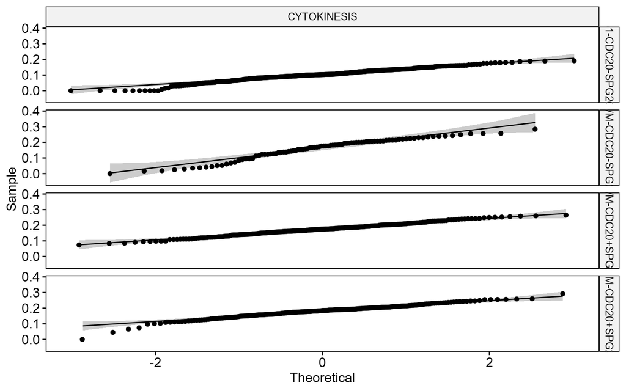

```
## [1] "SKEWNESS -0.269799080275598"
## [1] "### ONE WAY ANOVA"
##               Df Sum Sq Mean Sq F value Pr(>F)
## class          3  1.269  0.4231   250.1 <2e-16 ***
## Residuals   1010  1.708  0.0017
## ---
## Signif. codes:  0 '***' 0.001 '**' 0.01 '*' 0.05 '.' 0.1 ' ' 1
## [1] " ##### USING PARAMETRIC SIGNIFICANCE TESTING ####"
```

```r
auc_glotzer_spg <- function(dryrun = FALSE) {
  sigs <- tab2sig("final_data/signatures/CYTOKINESES_GLOTZER.txt")
  sigs <- as.data.frame(sigs)
  set.seed(1000)
  cells_rankings <- AUCell_buildRankings(cd, nCores=4, plotStats=FALSE)
  cells_AUC <- AUCell_calcAUC(sigs, cells_rankings)
  dat <- as.data.frame(t(getAUC(cells_AUC)))
  dat$class <- sg
  dat <- melt(dat, id.vars = c("class"))
  dat$class <- factor(dat$class, labels = c("G1-CDC20-SPG20-",
                                        "G2/M-CDC20-SPG20-",
                                        "G2/M-CDC20+SPG20-",
                                        "G2/M-CDC20+SPG20+"))
  comparisons <- list( c("G2/M-CDC20+SPG20-", "G2/M-CDC20+SPG20+"))
  plot_auc(dat, comparisons = comparisons, dryrun = dryrun) +
    scale_color_discrete(labels=c(expression(paste("G1-", italic("CDC20"), ""^low, italic("SPG20"), ""^low,)),
                                  expression(paste("G2/M-", italic("CDC20"), ""^low, italic("SPG20"), ""^low,)),
                                  expression(paste("G2/M-", italic("CDC20"), ""^high, italic("SPG20"), ""^low,)),
                                  expression(paste("G2/M-", italic("CDC20"), ""^high, italic("SPG20"), ""^high,)))) +
    theme(legend.text.align = 0)
}

p <- auc_glotzer_spg() +
    labs(color="") +
    guides(color = guide_legend(override.aes = list(size = 4)))
```

```r
pdf(file="fig6h.pdf", width = 1300/300, height=900/300, family = font_family)
print(p)
dev.off()
```

For the supplemental figure 4b, we plotted some top genes accross populations.

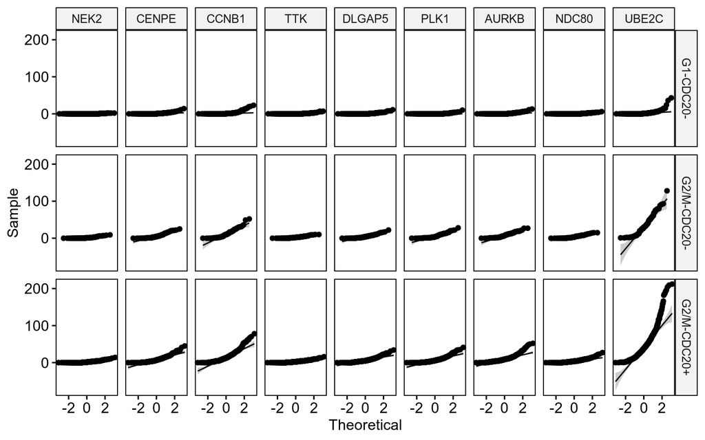

```
## [1] "SKEWNESS 5.28684835521343"
## [1] "Permuted Wald Type Test (GFD package):"
## Call:
## value ~ class + variable
## <environment: 0x56436096ae30>
##
## Wald-Type Statistic (WTS):
##          Test statistic df p-value p-value WTPS
## class          3333.943  2       0            0
## variable       3320.521 24       0            0
##
## ANOVA-Type Statistic (ATS):
##          Test statistic      df1      df2 p-value
## class          537.2532 1.362200 288.2683       0
## variable       177.1323 2.895583 288.2683       0
## [1] " ##### USING PERMUTATION BASED SIGNIFICANCE TESTING ####"
```

```r
cd <- readRDS("final_data/filtered_count_matrix.rds")
pd <- readRDS("final_data/cycling_metadata.rds")
sg <- pd$type_cdc20
sg <- sg[which(pd$barcode %in% colnames(cd))]
names(sg) <- colnames(cd)
sg <- factor(sg)

gg <- c("NEK2", "CENPE", "CCNB1", "TTK", "DLGAP5", "PLK1", "AURKB", "NDC80", "UBE2C")
dat <- as.data.frame(t(cd[gg, ]))
  dat$class <- factor(sg, labels = c("G1-CDC20-",
                                        "G2/M-CDC20-",
                                        "G2/M-CDC20+"))
dat.m <- melt(dat, id.vars="class")

comparisons <- list( c("G2/M-CDC20+", "G2/M-CDC20-"),
                 c("G1-CDC20-", "G2/M-CDC20-"),
                 c("G1-CDC20-", "G2/M-CDC20+"))

# these are not auc scores, but our plotting function will work for this data as well.
p <- plot_auc(dat.m, comparisons = comparisons, scales="free", dryrun = FALSE) +
    scale_color_discrete(labels=c(expression(paste("G1-", italic("CDC20"), ""^low)),
                                  expression(paste("G2/M-", italic("CDC20"), ""^low)),
                                  expression(paste("G2/M-", italic("CDC20"), ""^high)))) +
    theme(legend.text.align = 0) +
    labs(color="")
```

```r
pdf(file="figS4b.pdf", width = 2000/300, height=1800/300, family = font_family)
print(p)
dev.off()
```